# Analisis Keterlambatan Pengembalian Film pada Database Sakila

Bagus Permana

2026-05-25

# **BAB 1: Pendahuluan**

Industri penyewaan film kini mulai tergeser dengan platform streaming digital, tapi model bisnis ini masih relevan untuk dianalisis karena banyak toko penyewaan fisik yang masih beroperasi, terutama di daerah dengan akses internet terbatas. Keterlambatan pengembalian film adalah masalah klasik yang mempengaruhi operasional dan pendapatan toko Database Sakila, yang merupakan simulasi sistem toko penyewaan film dengan ribuan data transaksi nyata, menyimpan informasi lengkap mulai dari data pelanggan, judul film, durasi sewa, hingga histori pembayaran, sehingga menjadi sumber data yang ideal untuk menganalisis fenomena ini secara mendalam.

Permasalahan utama yang diangkat dalam analisis ini adalah belum adanya pemahaman yang sistematis mengenai seberapa besar tingkat keterlambatan pengembalian film, kategori film mana yang paling sering mengalami keterlambatan, dan seberapa signifikan kontribusi denda keterlambatan terhadap total pendapatan toko. Tanpa pemahaman ini, manajemen toko kesulitan menentukan kebijakan yang tepat sasaran, apakah perlu memperketat aturan, menyesuaikan durasi sewa, atau justru memanfaatkan pola keterlambatan sebagai bagian dari strategi pendapatan.

Berdasarkan latar belakang dan rumusan masalah tersebut, analisis ini bertujuan untuk mengidentifikasi pola keterlambatan pengembalian film secara menyeluruh menggunakan data dari database Sakila, mengukur kontribusi estimasi denda terhadap total pendapatan, serta menghasilkan rekomendasi strategis berbasis data yang dapat langsung diterapkan oleh manajemen toko untuk mengoptimalkan operasional dan pendapatan.

## 1.1 Library yang Digunakan

```r
library(DBI)
library(odbc)
library(dplyr)
library(ggplot2)
library(DT)
library(knitr)
library(kableExtra)
library(scales)
```

## 1.2 Koneksi ke Database Sakila

```r
# Koneksi ke MySQL (Sakila)
con <- DBI::dbConnect(
  odbc::odbc(),
  Driver   = "MySQL ODBC 8.0 ANSI Driver",
  Server   = "127.0.0.1",
  Database = "sakila",
  UID      = "root",
  PWD      = "*****",
  Port     = 3306
)
```

## 1.3 Pengambilan Data dari Database My SQL

```r
# Query utama: ambil semua data yang dibutuhkan sekaligus
df_raw <- dbGetQuery(con, "
  SELECT
    r.rental_id,
    r.customer_id,
    r.rental_date,
    r.return_date,
    f.title,
    f.rental_duration,
    f.rental_rate,
    f.length            AS durasi_film_menit,
    f.rating,
    f.replacement_cost,
    c.name              AS category,
    cu.first_name,
    cu.last_name,
    ci.city,
    co.country,
    COALESCE(p.amount, 0) AS payment_amount,
    st.store_id
  FROM rental r
  JOIN inventory     i   ON r.inventory_id  = i.inventory_id
  JOIN film          f   ON i.film_id       = f.film_id
  JOIN film_category fc  ON f.film_id       = fc.film_id
  JOIN category      c   ON fc.category_id  = c.category_id
  JOIN customer      cu  ON r.customer_id   = cu.customer_id
  JOIN address       ad  ON cu.address_id   = ad.address_id
  JOIN city          ci  ON ad.city_id      = ci.city_id
  JOIN country       co  ON ci.country_id   = co.country_id
  LEFT JOIN payment  p   ON r.rental_id     = p.rental_id
  JOIN staff         s   ON r.staff_id      = s.staff_id
  JOIN store         st  ON s.store_id      = st.store_id
  WHERE r.return_date IS NOT NULL
  ORDER BY r.rental_date
")

cat(sprintf( "Total baris data : %s\nTotal kolom      : %d\n",
  format(nrow(df_raw), big.mark = ","),
  ncol(df_raw)
))
```

```
## Total baris data : 15,861
## Total kolom      : 17
```

## 1.4 Preview Data Mentah

```r
datatable(
  head(df_raw, 200),
  options = list(
    pageLength = 10,
    lengthMenu = c(10, 25, 50),
    scrollX    = TRUE,
    dom        = 'lfrtip',
    language   = list(search = "Cari:")
  ),
  caption = "Tabel 1. Pratinjau 200 baris pertama data penyewaan"
)
```

|  | rental_id | customer_id | rental_date | return_date | title | rental_duration | rental_rate | durasi_film_menit | rating | replacement_cost | category | first_name | last_name | city | country | payment_amount | store_id |
| --- | --- | --- | --- | --- | --- | --- | --- | --- | --- | --- | --- | --- | --- | --- | --- | --- | --- |
| 1 | 1 | 130 | 2005-05-24T22:53:30Z | 2005-05-26T22:04:30Z | BLANKET BEVERLY | 7 | 2.99 | 148 | G | 21.99 | Family | CHARLOTTE | HUNTER | Águas Lindas de Goiás | Brazil | 2.99 | 1 |
| 2 | 2 | 459 | 2005-05-24T22:54:33Z | 2005-05-28T19:40:33Z | FREAKY POCUS | 7 | 2.99 | 126 | R | 16.99 | Music | TOMMY | COLLAZO | Qomsheh | Iran | 2.99 | 1 |
| 3 | 3 | 408 | 2005-05-24T23:03:39Z | 2005-06-01T22:12:39Z | GRADUATE LORD | 7 | 2.99 | 156 | G | 14.99 | Children | MANUEL | MURRELL | Jaffna | Sri Lanka | 3.99 | 1 |
| 4 | 4 | 333 | 2005-05-24T23:04:41Z | 2005-06-03T01:43:41Z | LOVE SUICIDES | 6 | 0.99 | 181 | R | 21.99 | Horror | ANDREW | PURDY | Baku | Azerbaijan | 4.99 | 2 |
| 5 | 5 | 222 | 2005-05-24T23:05:21Z | 2005-06-02T04:33:21Z | IDOLS SNATCHERS | 5 | 2.99 | 84 | NC-17 | 29.99 | Children | DELORES | HANSEN | Jaroslavl | Russian Federation | 6.99 | 1 |
| 6 | 6 | 549 | 2005-05-24T23:08:07Z | 2005-05-27T01:32:07Z | MYSTIC TRUMAN | 5 | 0.99 | 92 | NC-17 | 19.99 | Comedy | NELSON | CHRISTENSON | Santiago de Compostela | Spain | 0.99 | 1 |
| 7 | 7 | 269 | 2005-05-24T23:11:53Z | 2005-05-29T20:34:53Z | SWARM GOLD | 4 | 0.99 | 123 | PG-13 | 12.99 | Horror | CASSANDRA | WALTERS | Salinas | United States | 1.99 | 2 |
| 8 | 8 | 239 | 2005-05-24T23:31:46Z | 2005-05-27T23:33:46Z | LAWLESS VISION | 6 | 4.99 | 181 | G | 29.99 | Animation | MINNIE | ROMERO | Ciomas | Indonesia | 4.99 | 2 |
| 9 | 9 | 126 | 2005-05-25T00:00:40Z | 2005-05-28T00:22:40Z | MATRIX SNOWMAN | 6 | 4.99 | 56 | PG-13 | 9.99 | Foreign | ELLEN | SIMPSON | Poá | Brazil | 4.99 | 1 |
| 10 | 10 | 399 | 2005-05-25T00:02:21Z | 2005-05-31T22:44:21Z | HANGING DEEP | 5 | 4.99 | 62 | G | 18.99 | Drama | DANNY | ISOM | Okara | Pakistan | 5.99 | 2 |

[output cut: 190 more lines]

# **BAB 2: Transformasi Data**

```r
df <- df_raw %>%
  mutate(
    # Konversi tipe data datetime
    rental_date  = as.POSIXct(rental_date),
    return_date  = as.POSIXct(return_date),

    # Hitung durasi aktual penyewaan dalam hari
    actual_days  = as.numeric(difftime(return_date, rental_date, units = "days")),

    # Selisih antara durasi aktual vs durasi yang diizinkan
    # Nilai positif = terlambat, negatif/nol = tepat waktu
    late_days    = actual_days - rental_duration,

    # Estimasi denda: setiap hari keterlambatan dikali rental_rate
    # Jika tidak terlambat, denda = 0
    denda        = ifelse(late_days > 0, late_days * rental_rate, 0),

    # Kategorisasi status pengembalian berdasarkan jumlah hari terlambat
    status = case_when(
      late_days <= 0 ~ "Tepat Waktu",
      late_days <= 3 ~ "Terlambat Ringan",
      late_days <= 7 ~ "Terlambat Sedang",
      TRUE           ~ "Terlambat Parah"
    ),

    # Fitur temporal untuk analisis tren
    bulan        = format(rental_date, "%Y-%m"),
    tahun        = format(rental_date, "%Y"),
    hari_minggu  = weekdays(rental_date),

    # Nama lengkap pelanggan
    nama_pelanggan = paste(first_name, last_name),

    # Flag boolean: apakah transaksi ini terlambat
    is_late      = late_days > 0
  ) %>%
  mutate(
    # Urutan hari yang benar (faktor terurut)
    hari_minggu = factor(
      hari_minggu,
      levels = c("Monday","Tuesday","Wednesday","Thursday","Friday","Saturday","Sunday"),
      labels = c("Sen","Sel","Rab","Kam","Jum","Sab","Min")
    ),
    # Urutan status dari yang paling baik ke paling buruk
    status = factor(
      status,
      levels = c("Tepat Waktu","Terlambat Ringan","Terlambat Sedang","Terlambat Parah")
    )
  )

glimpse(df)
```

```
## Rows: 15,861
## Columns: 26
## $ rental_id         <int> 1, 2, 3, 4, 5, 6, 7, 8, 9, 10, 11, 12, 13, 14, 15, 1…
## $ customer_id       <int> 130, 459, 408, 333, 222, 549, 269, 239, 126, 399, 14…
## $ rental_date       <dttm> 2005-05-24 22:53:30, 2005-05-24 22:54:33, 2005-05-2…
## $ return_date       <dttm> 2005-05-26 22:04:30, 2005-05-28 19:40:33, 2005-06-0…
## $ title             <chr> "BLANKET BEVERLY", "FREAKY POCUS", "GRADUATE LORD", …
## $ rental_duration   <int> 7, 7, 7, 6, 5, 5, 4, 6, 6, 5, 4, 7, 3, 6, 4, 6, 7, 7…
## $ rental_rate       <dbl> 2.99, 2.99, 2.99, 0.99, 2.99, 0.99, 0.99, 4.99, 4.99…
## $ durasi_film_menit <int> 148, 126, 156, 181, 84, 92, 123, 181, 56, 62, 109, 1…
## $ rating            <chr> "G", "R", "G", "R", "NC-17", "NC-17", "PG-13", "G", …
## $ replacement_cost  <dbl> 21.99, 16.99, 14.99, 21.99, 29.99, 19.99, 12.99, 29.…
## $ category          <chr> "Family", "Music", "Children", "Horror", "Children",…
## $ first_name        <chr> "CHARLOTTE", "TOMMY", "MANUEL", "ANDREW", "DELORES",…
## $ last_name         <chr> "HUNTER", "COLLAZO", "MURRELL", "PURDY", "HANSEN", "…
## $ city              <chr> "Águas Lindas de Goiás", "Qomsheh", "Jaffna", "Baku"…
## $ country           <chr> "Brazil", "Iran", "Sri Lanka", "Azerbaijan", "Russia…
## $ payment_amount    <dbl> 2.99, 2.99, 3.99, 4.99, 6.99, 0.99, 1.99, 4.99, 4.99…
## $ store_id          <int> 1, 1, 1, 2, 1, 1, 2, 2, 1, 2, 2, 2, 1, 1, 1, 2, 1, 2…
## $ actual_days       <dbl> 1.9659722, 3.8652778, 7.9645833, 9.1104167, 8.227777…
## $ late_days         <dbl> -5.0340278, -3.1347222, 0.9645833, 3.1104167, 3.2277…
## $ denda             <dbl> 0.0000000, 0.0000000, 2.8841042, 3.0793125, 9.651055…
## $ status            <fct> Tepat Waktu, Tepat Waktu, Terlambat Ringan, Terlamba…
## $ bulan             <chr> "2005-05", "2005-05", "2005-05", "2005-05", "2005-05…
## $ tahun             <chr> "2005", "2005", "2005", "2005", "2005", "2005", "200…
## $ hari_minggu       <fct> Sel, Sel, Sel, Sel, Sel, Sel, Sel, Sel, Rab, Rab, Ra…
## $ nama_pelanggan    <chr> "CHARLOTTE HUNTER", "TOMMY COLLAZO", "MANUEL MURRELL…
## $ is_late           <lgl> FALSE, FALSE, TRUE, TRUE, TRUE, FALSE, TRUE, FALSE, …
```

**Hasil Transformasi.** Proses transformasi data menghasilkan 9 kolom baru yang masing-masing punya peran spesifik dalam analisis. Kolom `actual_days` dihitung dari selisih `return_date` dan `rental_date` untuk mengetahui berapa hari nyata pelanggan memegang film. Dari situ lahir `late_days`, yaitu selisih antara durasi aktual dengan durasi yang diizinkan, nilai positif berarti terlambat dan negatif berarti lebih cepat dari batas. Kolom `denda` dihitung hanya jika `late_days > 0` dengan mengalikan jumlah hari terlambat dengan `rental_rate`, sehingga pelanggan tepat waktu otomatis dendanya nol. Kolom `status` mengkategorikan tingkat keterlambatan menjadi empat kelompok (Tepat Waktu, Terlambat Ringan, Sedang, Parah) agar analisis bisa dilakukan per segmen, bukan hanya angka mentah. Kolom `bulan` dan `tahun` diekstrak dari `rental_date` untuk keperluan analisis tren temporal, sedangkan `hari_minggu` diubah menjadi faktor terurut agar visualisasi per hari tampil berurutan Sen sampai Min. Kolom `nama_pelanggan` menggabungkan `first_name` dan `last_name` untuk kemudahan identifikasi di tabel segmentasi. Terakhir, `is_late` adalah flag boolean TRUE/FALSE yang menjadi dasar semua perhitungan persentase keterlambatan di seluruh analisis ini.

# **BAB 3: Ringkasan Statistik Deskriptif**

```r
# Hitung semua metrik utama
total_transaksi     <- nrow(df)
total_terlambat     <- sum(df$is_late, na.rm = TRUE)
persen_terlambat    <- round(total_terlambat / total_transaksi * 100, 1)
rata_terlambat      <- round(mean(df$late_days[df$is_late], na.rm = TRUE), 1)
median_terlambat    <- round(median(df$late_days[df$is_late], na.rm = TRUE), 1)
max_terlambat       <- max(df$late_days, na.rm = TRUE)
min_terlambat       <- min(df$late_days[df$is_late], na.rm = TRUE)
sd_terlambat            <- round(sd(df$late_days[df$is_late], na.rm = TRUE), 2)
total_denda         <- round(sum(df$denda, na.rm = TRUE), 2)
total_revenue       <- round(sum(df$payment_amount, na.rm = TRUE), 2)
kontribusi_denda    <- round(total_denda / total_revenue * 100, 1)
avg_denda_per_kasus <- round(total_denda / total_terlambat, 2)
max_denda           <- round(max(df$denda, na.rm = TRUE), 2)

# Tampilkan tabel ringkasan
ringkasan <- data.frame(
  Statistik = c(
    "Total Transaksi",
    "Transaksi Terlambat",
    "Transaksi Tepat Waktu",
    "Persentase Keterlambatan",
    "Rata-rata Hari Terlambat",
    "Median Hari Terlambat",
    "Std Dev Hari Terlambat",
    "Keterlambatan Maksimum",
    "Estimasi Total Denda",
    "Total Pendapatan",
    "Kontribusi Denda (%)",
    "Rata-rata Denda per Kasus",
    "Denda Terbesar (1 transaksi)"
  ),
  Nilai = c(
    format(total_transaksi, big.mark = ","),
    paste0(format(total_terlambat, big.mark = ","), " (", persen_terlambat, "%)"),
    paste0(format(total_transaksi - total_terlambat, big.mark = ","),
           " (", 100 - persen_terlambat, "%)"),
    paste0(persen_terlambat, "%"),
    paste0(rata_terlambat, " hari"),
    paste0(median_terlambat, " hari"),
    paste0(sd_terlambat, " hari"),
    paste0(round(max_terlambat, 1), " hari"),
    paste0("$", format(total_denda, big.mark = ",")),
    paste0("$", format(total_revenue, big.mark = ",")),
    paste0(kontribusi_denda, "%"),
    paste0("$", avg_denda_per_kasus),
    paste0("$", max_denda)
  )
)

knitr::kable(
  ringkasan,
  format     = "html",
  col.names  = c("Metrik", "Nilai"),
  align      = c("l", "r"),
  table.attr = "class='tabel-ringkasan'"
)
```

| Metrik | Nilai |
| --- | --- |
| Total Transaksi | 15,861 |
| Transaksi Terlambat | 8,121 (51.2%) |
| Transaksi Tepat Waktu | 7,740 (48.8%) |
| Persentase Keterlambatan | 51.2% |
| Rata-rata Hari Terlambat | 2.5 hari |
| Median Hari Terlambat | 2.1 hari |
| Std Dev Hari Terlambat | 1.63 hari |
| Keterlambatan Maksimum | 6.2 hari |
| Estimasi Total Denda | $58,692.14 |
| Total Pendapatan | $66,888.39 |
| Kontribusi Denda (%) | 87.7% |
| Rata-rata Denda per Kasus | $7.23 |
| Denda Terbesar (1 transaksi) | $31.18 |

**Interpretasi Statistik Deskriptif.** Dari total 15.861 transaksi yang dianalisis, sebanyak 8.121 transaksi atau 51.2% mengalami keterlambatan pengembalian, angka yang cukup mengkhawatirkan karena artinya lebih dari separuh pelanggan tidak mengembalikan film tepat waktu. Rata-rata keterlambatan tercatat 2.5 hari dengan median 2.1 hari, selisih antara keduanya mengindikasikan adanya sebagian kecil kasus dengan keterlambatan ekstrem yang menarik nilai rata-rata ke atas, hal ini diperkuat oleh nilai maksimum keterlambatan yang mencapai 6.2 hari. Standar deviasi sebesar 1.63 hari menunjukkan bahwa sebaran keterlambatan relatif tidak terlalu lebar, artinya sebagian besar keterlambatan memang berkumpul di kisaran 1 hingga 4 hari. Yang paling menarik perhatian adalah kontribusi denda terhadap pendapatan yang mencapai 87.7%, dengan estimasi total denda $58.692,14 dari total pendapatan $66.888,39. Angka ini sangat tinggi dan mengindikasikan bahwa model perhitungan denda dalam data simulasi ini terlalu dominan dibanding pendapatan sewa normal, sehingga perlu diperhatikan bahwa formula estimasi denda yang digunakan bersifat kumulatif dan bisa jadi melebihi nilai sewa aslinya pada kasus keterlambatan yang panjang.

## 3.1 Distribusi per Status Pengembalian

```r
tbl_status <- df %>%
  dplyr::group_by(status) %>%
  dplyr::summarise(
    Jumlah         = n(),
    Persentase     = paste0(round(n() / nrow(df) * 100, 1), "%"),
    RataRataterlambat  = round(mean(late_days, na.rm = TRUE), 1),
    TotalDenda     = paste0("$", format(round(sum(denda, na.rm = TRUE), 2), big.mark = ",")),
    AvgDendaKasus  = ifelse(
      any(denda > 0),
      paste0("$", round(mean(denda[denda > 0], na.rm = TRUE), 2)),
      "$0"
    ),
    .groups = "drop"
  ) %>%
  dplyr::arrange(status)

knitr::kable(
  tbl_status,
  format     = "html",
  caption    = "Tabel 2. Ringkasan Statistik per Status Pengembalian",
  col.names  = c("Status", "Jumlah", "Persentase",
                 "Rata-rata terlambat (hari)", "Total Denda ($)", "Rata-rata Denda per Kasus" ),
  align      = "lrrrrrr",
  table.attr = "class='tabel-ringkasan'"
)
```

Tabel 2. Ringkasan Statistik per Status Pengembalian

| Status | Jumlah | Persentase | Rata-rata terlambat (hari) | Total Denda ($) | Rata-rata Denda per Kasus |
| --- | --- | --- | --- | --- | --- |
| Tepat Waktu | 7740 | 48.8% | -2.4 | $0 | $0 |
| Terlambat Ringan | 5201 | 32.8% | 1.5 | $22,378.68 | $4.3 |
| Terlambat Sedang | 2920 | 18.4% | 4.3 | $36,313.46 | $12.44 |

# **BAB 4: Visualisasi Data**

## 4.1 Distribusi Hari Keterlambatan

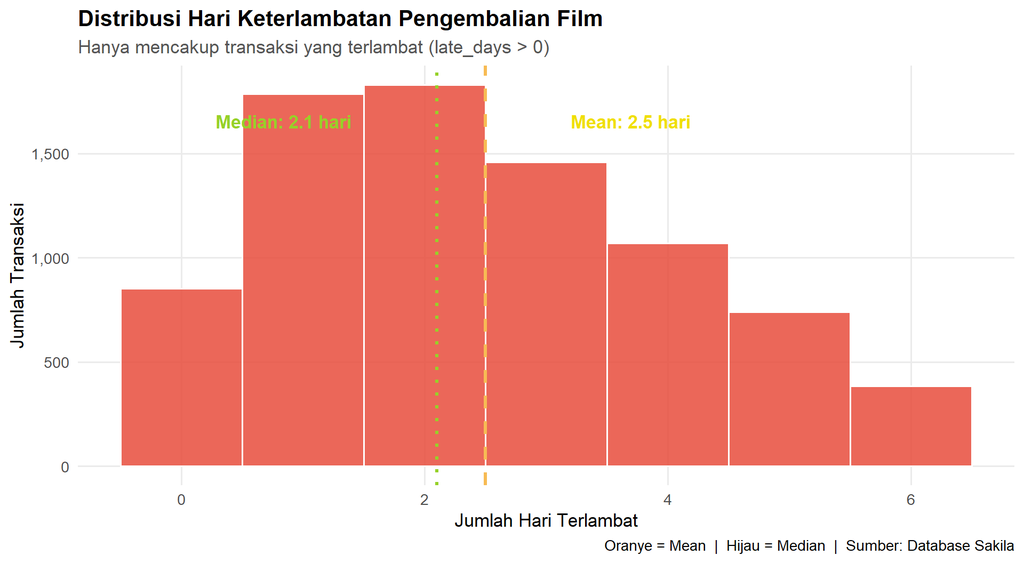

```r
ggplot(df %>% filter(is_late), aes(x = late_days)) +
  geom_histogram(
    binwidth = 1,
    fill     = "#e74c3c",
    color    = "white",
    alpha    = 0.85
  ) +
  geom_vline(
    xintercept = rata_terlambat,
    linetype   = "dashed",
    color      = "#F7BB54",
    linewidth  = 1.1
  ) +
  geom_vline(
    xintercept = median_terlambat,
    linetype   = "dotted",
    color      = "#96D128",
    linewidth  = 1.1
  ) +
  annotate(
    "text",
    x      = rata_terlambat + 0.7,
    y      = Inf,
    label  = paste0("Mean: ", rata_terlambat, " hari"),
    color  = "#F0DF05",
    vjust  = 4.5,
    hjust  = 0,
    size   = 4.5,
    fontface = "bold"
  ) +
  annotate(
    "text",
    x      = median_terlambat - 0.7,
    y      = Inf,
    label  = paste0("Median: ", median_terlambat, " hari"),
    color  = "#96D128",
    vjust  = 4.5,
    hjust  = 1,
    size   = 4.5,
    fontface = "bold"
  ) +
  scale_x_continuous(breaks = seq(0, ceiling(max_terlambat), by = 2)) +
  scale_y_continuous(labels = label_comma()) +
  labs(
    title    = "Distribusi Hari Keterlambatan Pengembalian Film",
    subtitle = "Hanya mencakup transaksi yang terlambat (late_days > 0)",
    x        = "Jumlah Hari Terlambat",
    y        = "Jumlah Transaksi",
    caption  = "Oranye = Mean  |  Hijau = Median  |  Sumber: Database Sakila"
  ) +
  theme_minimal(base_size = 13) +
  theme(
    plot.title    = element_text(face = "bold"),
    plot.subtitle = element_text(color = "#555555"),
    panel.grid.minor = element_blank()
  )
```

**Interpretasi.** Histogram di atas menunjukkan distribusi keterlambatan yang berbentuk mound dengan puncak di sekitar 2 hari, kemudian menurun secara bertahap ke kanan hingga batas maksimum 6.2 hari. Nilai median 2.1 hari (garis hijau) lebih rendah dari mean 2.5 hari (garis oranye), perbedaan ini membuktikan adanya ekor kanan yang meskipun tidak terlalu panjang tetap cukup menarik rata-rata naik dari nilai tengah sebenarnya. Batang pertama di sekitar 0-1 hari yang cukup tinggi menunjukkan banyak pelanggan yang hanya terlambat sehari, kemungkinan besar karena lupa atau salah hitung tanggal jatuh tempo, bukan karena niat sengaja menunda pengembalian.

## 4.2 Proporsi Status Pengembalian

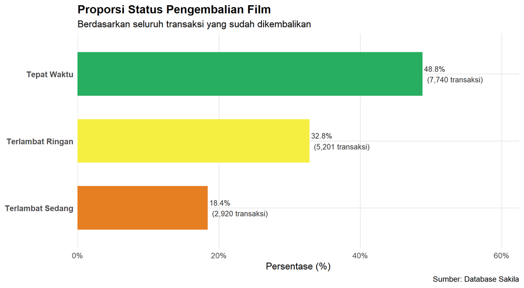

```r
df %>%
  count(status) %>%
  mutate(
    persen = round(n / sum(n) * 100, 1),
    label  = paste0(persen, "%\n(", format(n, big.mark = ","), " transaksi)")
  ) %>%
  ggplot(aes(x = reorder(status, persen), y = persen, fill = status)) +
  geom_col(show.legend = FALSE, width = 0.65) +
  geom_text(
    aes(label = label),
    hjust  = -0.08,
    color  = "#333333",
    size   = 3.6
  ) +
  coord_flip() +
  scale_fill_manual(values = c(
    "Tepat Waktu"       = "#27ae60",
    "Terlambat Ringan"  = "#F5EF42",
    "Terlambat Sedang"  = "#e67e22",
    "Terlambat Parah"   = "#e74c3c"
  )) +
  scale_y_continuous(
    expand = expansion(mult = c(0, 0.28)),
    labels = function(x) paste0(x, "%")
  ) +
  labs(
    title    = "Proporsi Status Pengembalian Film",
    subtitle = "Berdasarkan seluruh transaksi yang sudah dikembalikan",
    x        = NULL,
    y        = "Persentase (%)",
    caption  = "Sumber: Database Sakila"
  ) +
  theme_minimal(base_size = 13) +
  theme(
    plot.title       = element_text(face = "bold"),
    panel.grid.minor = element_blank(),
    axis.text.y      = element_text(size = 11, face = "bold")
  )
```

## 4.3 Tren Pendapatan Bulanan: Sewa Normal vs Denda

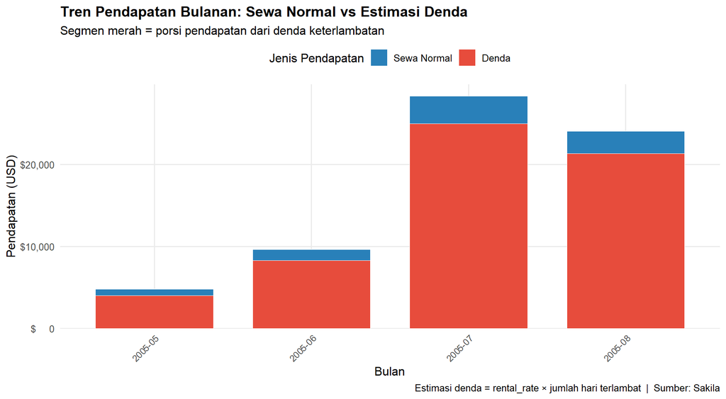

```r
# Agregasi per bulan
df_tren <- df %>%
  group_by(bulan) %>%
  summarise(
    Normal = sum(payment_amount - denda, na.rm = TRUE),
    Denda  = sum(denda, na.rm = TRUE),
    .groups = "drop"
  ) %>%
  arrange(bulan)

# Reshape ke format long tanpa tidyr
df_tren_long <- rbind(
  data.frame(bulan = df_tren$bulan, jenis = "Sewa Normal", nilai = df_tren$Normal),
  data.frame(bulan = df_tren$bulan, jenis = "Denda",       nilai = df_tren$Denda)
) %>%
  mutate(jenis = factor(jenis, levels = c("Sewa Normal", "Denda")))

ggplot(df_tren_long, aes(x = bulan, y = nilai, fill = jenis)) +
  geom_col(position = "stack", width = 0.75, color = "white", linewidth = 0.3) +
  scale_fill_manual(values = c("Sewa Normal" = "#2980b9", "Denda" = "#e74c3c")) +
  scale_y_continuous(
    labels   = function(x) paste0("$", format(round(x), big.mark = ",")),
    expand   = expansion(mult = c(0, 0.05))
  ) +
  labs(
    title    = "Tren Pendapatan Bulanan: Sewa Normal vs Estimasi Denda",
    subtitle = "Segmen merah = porsi pendapatan dari denda keterlambatan",
    x        = "Bulan",
    y        = "Pendapatan (USD)",
    fill     = "Jenis Pendapatan",
    caption  = "Estimasi denda = rental_rate \u00d7 jumlah hari terlambat  |  Sumber: Sakila"
  ) +
  theme_minimal(base_size = 12) +
  theme(
    axis.text.x      = element_text(angle = 45, hjust = 1, size = 9),
    plot.title       = element_text(face = "bold"),
    legend.position  = "top",
    panel.grid.minor = element_blank()
  )
```

**Interpretasi.** Grafik ini mengungkap fakta menarik bahwa porsi merah (denda) secara konsisten mendominasi setiap batang di semua bulan dari Mei hingga Agustus 2005, bahkan di bulan Juli yang merupakan puncak transaksi terbanyak, segmen denda tetap proporsional besar. Tren pendapatan meningkat tajam dari Mei ke Juli lalu sedikit turun di Agustus, pola yang kemungkinan mencerminkan siklus musiman penyewaan DVD. Yang paling krusial adalah dominasi warna merah di setiap bulan membuktikan bahwa denda bukan pendapatan kebetulan melainkan komponen struktural yang bisa diproyeksikan, dan jika kebijakan denda diubah drastis maka proyeksi pendapatan toko perlu direvisi total.

## 4.4 Persentase Keterlambatan per Kategori Film

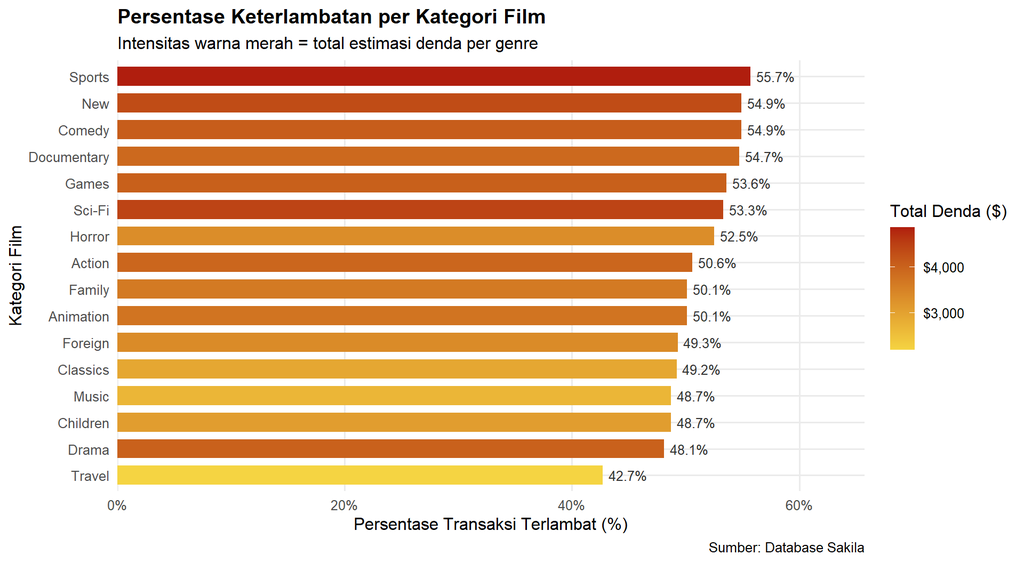

```r
df_kategori <- df %>%
  group_by(category) %>%
  summarise(
    persen_terlambat    = round(mean(is_late, na.rm = TRUE) * 100, 1),
    total_denda     = round(sum(denda, na.rm = TRUE), 2),
    total_transaksi = n(),
    .groups         = "drop"
  )

ggplot(df_kategori,
       aes(x    = reorder(category, persen_terlambat),
           y    = persen_terlambat,
           fill = total_denda)) +
  geom_col(width = 0.72) +
  geom_text(
    aes(label = paste0(persen_terlambat, "%")),
    hjust  = -0.15,
    color  = "#333333",
    size   = 3.4
  ) +
  coord_flip() +
  scale_fill_gradient(
    low    = "#F5D442",
    high   = "#B01E0E",
    labels = function(x) paste0("$", format(round(x), big.mark = ","))
  ) +
  scale_y_continuous(
    expand = expansion(mult = c(0, 0.18)),
    labels = function(x) paste0(x, "%")
  ) +
  labs(
    title    = "Persentase Keterlambatan per Kategori Film",
    subtitle = "Intensitas warna merah = total estimasi denda per genre",
    x        = "Kategori Film",
    y        = "Persentase Transaksi Terlambat (%)",
    fill     = "Total Denda ($)",
    caption  = "Sumber: Database Sakila"
  ) +
  theme_minimal(base_size = 12) +
  theme(
    plot.title       = element_text(face = "bold"),
    legend.position  = "right",
    panel.grid.minor = element_blank()
  )
```

# **BAB 5: Analisis Statistik Inferensial**

## 5.1 Uji Korelasi: Hari Keterlambatan vs Jumlah Pembayaran

**Tujuan uji korelasi:** Uuntuk mengetahui apakah semakin lama keterlambatan, semakin besar pembayaran yang diterima? Secara teoritis ya (karena ada tambahan denda), tapi seberapa kuat hubungannya secara statistik perlu diuji secara formal menggunakan Pearson correlation.

```r
cor_result <- cor.test(df$late_days, df$payment_amount, method = "pearson")

interpretasi_r <- ifelse(
  abs(cor_result$estimate) > 0.7, "Korelasi sangat kuat",
  ifelse(abs(cor_result$estimate) > 0.5, "Korelasi kuat",
    ifelse(abs(cor_result$estimate) > 0.3, "Korelasi moderat",
      ifelse(abs(cor_result$estimate) > 0.1, "Korelasi lemah", "Tidak ada korelasi")))
)

cat(sprintf(
"=== UJI KORELASI PEARSON ===
Koefisien Korelasi (r) : %.4f
t-statistik            : %.4f
Derajat Kebebasan (df) : %d
p-value                : %.2e
95%% CI                : [%.4f, %.4f]
Interpretasi           : %s
Signifikansi           : %s",
  cor_result$estimate,
  cor_result$statistic,
  cor_result$parameter,
  cor_result$p.value,
  cor_result$conf.int[1],
  cor_result$conf.int[2],
  interpretasi_r,
  ifelse(cor_result$p.value < 0.05, "Signifikan (p < 0.05)", "Tidak signifikan")
))
```

```
## === UJI KORELASI PEARSON ===
## Koefisien Korelasi (r) : 0.6216
## t-statistik            : 99.9219
## Derajat Kebebasan (df) : 15859
## p-value                : 0.00e+00
## 95% CI                : [0.6119, 0.6310]
## Interpretasi           : Korelasi kuat
## Signifikansi           : Signifikan (p < 0.05)
```

Formula yang digunakan untuk menghitung korelasi Pearson adalah:

$$r_{Pearson} = \frac{\sum(X_i -
\bar{X})(Y_i - \bar{Y})}{\sqrt{\sum(X_i - \bar{X})^2 \cdot \sum(Y_i -
\bar{Y})^2}}$$

Di mana $X_i$ adalah nilai `late_days` pada transaksi ke-$i$, $Y_i$ adalah nilai `payment_amount` pada transaksi ke-$i$, $\bar{X}$ dan $\bar{Y}$ adalah rata-rata masing-masing variabel. Pembilang menghitung seberapa besar kedua variabel bergerak bersama-sama (kovarians), sedangkan penyebut menormalkan nilainya ke rentang -1 hingga +1. Nilai mendekati +1 berarti hubungan positif kuat, mendekati -1 berarti hubungan negatif kuat, dan mendekati 0 berarti tidak ada hubungan linear.

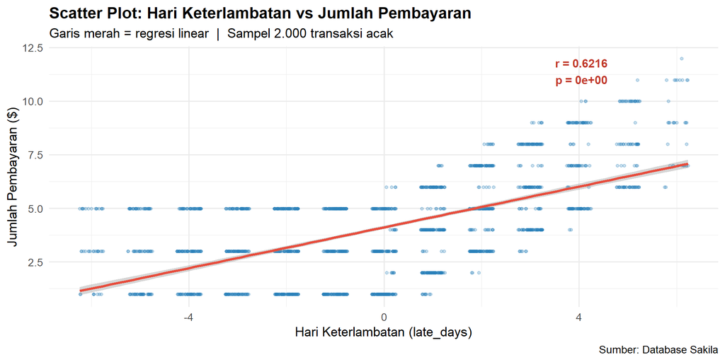

```r
# Sampel untuk visualisasi agar plot tidak terlalu berat
set.seed(99)
df_sample <- df %>%
  sample_n(min(2000, nrow(df)))

ggplot(df_sample, aes(x = late_days, y = payment_amount)) +
  geom_point(alpha = 0.25, size = 1.2, color = "#2980b9") +
  geom_smooth(method = "lm", color = "#e74c3c", linewidth = 1.2, se = TRUE) +
  annotate(
    "text",
    x     = max(df_sample$late_days, na.rm = TRUE) * 0.65,
    y     = max(df_sample$payment_amount, na.rm = TRUE) * 0.95,
    label = paste0("r = ", round(cor_result$estimate, 4),
                   "\np = ", format(cor_result$p.value, scientific = TRUE, digits = 3)),
    size  = 4,
    color = "#c0392b",
    fontface = "bold"
  ) +
  labs(
    title    = "Scatter Plot: Hari Keterlambatan vs Jumlah Pembayaran",
    subtitle = "Garis merah = regresi linear  |  Sampel 2.000 transaksi acak",
    x        = "Hari Keterlambatan (late_days)",
    y        = "Jumlah Pembayaran ($)",
    caption  = "Sumber: Database Sakila"
  ) +
  theme_minimal(base_size = 13) +
  theme(plot.title = element_text(face = "bold"))
```

# **BAB 6: Kesimpulan dan Rekomendasi**

## 6.1 Ringkasan Temuan

Tabel 8. Ringkasan Temuan Analisis

[output not shown]

## 6.2 Rekomendasi Strategis

**Rekomendasi 1: Jangan Intervensi Agresif untuk Keterlambatan Ringan (1-3 hari).** Segmen ini punya volume terbesar. Pendekatan terlalu keras berisiko merusak hubungan dengan mayoritas pelanggan. Cukup pengingat otomatis (SMS/email) satu hari sebelum jatuh tempo.

**Rekomendasi 4: Monitor Dua Toko Secara Terpisah.** Jika ada perbedaan signifikan antar toko, perlu investigasi apakah perbedaannya disebabkan demografi pelanggan, staf, atau kebijakan operasional yang berbeda. Benchmark silang antar toko bisa jadi sumber insight berharga.